# INFO526_FinalProject

Yuehting Wu & Peiwen Su

5/5/2022

# Description of dataset

This is a secondary analysis of an existing dataset using data obtained from [Kaggle, Cardiovascular Disease dataset] (https://www.kaggle.com/datasets/sulianova/cardiovascular-disease-dataset). The dataset contains 70000 records and 13 features which were collected at the moment of medical examination, such as systolic blood pressure, diastolic blood pressure, and having cardiovascular disease or not.

# Import the dataset

```r
# ENTER YOUR CODE HERE
cardiodisease <- read_csv("data/cardio.csv",
                          col_names = TRUE,
                  col_types = "iifiiiiffllll")
summary(cardiodisease)
```

```
##        id             age        gender        height          weight
##  Min.   :    0   Min.   :10798   2:24470   Min.   : 55.0   Min.   : 10.00
##  1st Qu.:25007   1st Qu.:17664   1:45530   1st Qu.:159.0   1st Qu.: 65.00
##  Median :50002   Median :19703             Median :165.0   Median : 72.00
##  Mean   :49972   Mean   :19469             Mean   :164.4   Mean   : 74.21
##  3rd Qu.:74889   3rd Qu.:21327             3rd Qu.:170.0   3rd Qu.: 82.00
##  Max.   :99999   Max.   :23713             Max.   :250.0   Max.   :200.00
##                                                            NA's   :193
##      ap_hi             ap_lo          cholesterol gluc        smoke
##  Min.   : -150.0   Min.   :  -70.00   1:52385     1:59479   Mode :logical
##  1st Qu.:  120.0   1st Qu.:   80.00   3: 8066     2: 5190   FALSE:63831
##  Median :  120.0   Median :   80.00   2: 9549     3: 5331   TRUE :6169
##  Mean   :  128.8   Mean   :   96.63
##  3rd Qu.:  140.0   3rd Qu.:   90.00
##  Max.   :16020.0   Max.   :11000.00
##
##     alco           active          cardio
##  Mode :logical   Mode :logical   Mode :logical
##  FALSE:66236     FALSE:13739     FALSE:35021
##  TRUE :3764      TRUE :56261     TRUE :34979
##
##
##
##
```

# Data preprocessing

First, drop missing value in the dataset. The columns of ap_hi and ap_lo stand for systolic and diastolic blood pressure which are impossible in the negative. So, filtering the dataset by the highest blood pressure in the world (https://pubmed.ncbi.nlm.nih.gov/7741618/) and people who have hypotension. And based on the blood pressure measurement, differentiate ap_hi and ap_lo into 5 categories in categorical type. Convert the age in days into the age in years and then change the data type from float to integer. Create a new feature called BMI, calculate the body mess index of each record. Based on the BMI, creating a new feature called BMI_level to distinguish BMI into 4 categories: underweight, normal, overweight, and obese and the BMI_level feature is in categorical type.

```r
# Drop missing value in the dataset
cardiodisease <- drop_na(cardiodisease)

# Filtering out impossible records
cardio_cleaning <- cardiodisease %>%
  filter(ap_hi <=370,ap_lo <=360,ap_lo >= 60, ap_lo <=360)

# distinguish systolic and diastolic into 5 categories: normal, prehypertension,
# stage 1, stage 2, and hypertension crisis
cardio_cleaning <- cardio_cleaning %>%
  mutate(blood_pressure = 1)
for (i in 1:length(cardio_cleaning$ap_hi)) {
  if(cardio_cleaning$ap_hi[i] >= 180 && cardio_cleaning$ap_lo[i] >= 120 ){
    cardio_cleaning$blood_pressure[i] <- "hypertension_crisis"
  } else if (cardio_cleaning$ap_hi[i]>= 140 || cardio_cleaning$ap_lo[i] >= 90) {
    cardio_cleaning$blood_pressure[i] <- "stage_2"
  } else if (cardio_cleaning$ap_hi[i]>= 130 || cardio_cleaning$ap_lo[i] >= 80) {
    cardio_cleaning$blood_pressure[i] <- "stage_1"
  } else if (cardio_cleaning$ap_hi[i] >= 120 && cardio_cleaning$ap_lo[i]<80){
    cardio_cleaning$blood_pressure[i] <- "hypertension"
  } else {
    cardio_cleaning$blood_pressure[i] <- "normal"
  }
}
cardio_cleaning$blood_pressure <- as.factor(cardio_cleaning$blood_pressure)


# Change data type
cardio_cleaning$age <- cardio_cleaning$age / 365
cardio_cleaning$age <- as.integer(cardio_cleaning$age)

# Create a new feature called BMI
cardio_cleaning <- cardio_cleaning %>%
  mutate(BMI = weight / ((height/100) * (height/100)))

# Create a new feature called BMI_level
cardio_cleaning <- cardio_cleaning %>%
  mutate(BMI_level = "normal")
for (i in 1: length(cardio_cleaning$BMI)){
  if(cardio_cleaning$BMI[i] < 18.5){
    cardio_cleaning$BMI_level[i] <- "underweight"
  } else if (cardio_cleaning$BMI[i] <= 24.9 && cardio_cleaning$BMI[i] >=18.5){
    cardio_cleaning$BMI_level[i]<- "normal"
  } else if (cardio_cleaning$BMI[i] <= 29.9 && cardio_cleaning$BMI[i] >= 25){
    cardio_cleaning$BMI_level[i] <- "overweight"
  } else{
    cardio_cleaning$BMI_level[i] <- "obese"
  }
}

cardio_cleaning$BMI_level <- as.factor(cardio_cleaning$BMI_level)



# The dataset we used for analyzing
cardio <- cardio_cleaning %>%
  select(-height, -weight, -ap_hi,-ap_lo,-id)

summary(cardio)
```

```
##       age        gender    cholesterol gluc        smoke
##  Min.   :29.00   2:23962   1:51514     1:58362   Mode :logical
##  1st Qu.:48.00   1:44689   3: 7866     2: 5053   FALSE:62635
##  Median :53.00             2: 9271     3: 5236   TRUE :6016
##  Mean   :52.83
##  3rd Qu.:58.00
##  Max.   :64.00
##     alco           active          cardio                    blood_pressure
##  Mode :logical   Mode :logical   Mode :logical   hypertension       : 3089
##  FALSE:64986     FALSE:13501     FALSE:34662     hypertension_crisis:  127
##  TRUE :3665      TRUE :55150     TRUE :33989     normal             : 9474
##                                                  stage_1            :32484
##                                                  stage_2            :23477
##
##       BMI                BMI_level
##  Min.   :  3.472   normal     :24390
##  1st Qu.: 23.875   obese      :19215
##  Median : 26.346   overweight :24412
##  Mean   : 27.525   underweight:  634
##  3rd Qu.: 30.119
##  Max.   :298.667
```

# First Visualization

```r
# Barplot
bloodpressure_cardio <- cardio %>%
  group_by(cardio, blood_pressure) %>%
  summarize(count = n())
print(bloodpressure_cardio)
```

```
## # A tibble: 10 × 3
## # Groups:   cardio [2]
##    cardio blood_pressure      count
##    <lgl>  <fct>               <int>
##  1 FALSE  hypertension         2089
##  2 FALSE  hypertension_crisis    25
##  3 FALSE  normal               7374
##  4 FALSE  stage_1             19992
##  5 FALSE  stage_2              5182
##  6 TRUE   hypertension         1000
##  7 TRUE   hypertension_crisis   102
##  8 TRUE   normal               2100
##  9 TRUE   stage_1             12492
## 10 TRUE   stage_2             18295
```

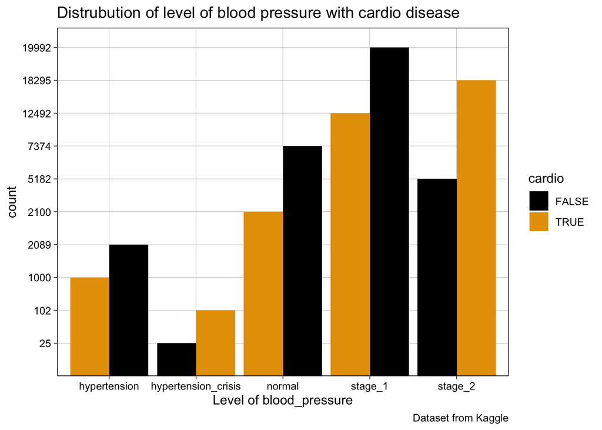

```r
bloodpressure_cardio %>%
  ggplot(aes(x= blood_pressure,
             y = reorder(count,blood_pressure),
             fill = cardio))+
  geom_col(position = "dodge")+
  scale_fill_colorblind()+
  labs(title = "Distrubution of level of blood pressure with cardio disease",
       caption = "Dataset from Kaggle",
       x = "Level of blood_pressure",
       y = "count")+
  theme_linedraw()
```

Interpretation of the visualization

This barplot shows the distributions of levels of blood pressure people whether who have the cardiovascular disease or not. For hypertension, people don’t have the disease more than having the disease. For hypertension crisis, people in this category are in the fewer proportion of the dataset. Most people in the hypertension crisis category have cardiovascular disease. Of the people with stage 2 hypertension, 78% (18295/23477) people have the disease. Of people in the normal group, 78% don’t have the disease.

# Second Visualization

```r
# Pie Chart
library(webr)
piechart <- cardio %>%
  group_by(cardio,BMI_level) %>%
  summarize(count = n())

piechart$cardio <- as.factor(piechart$cardio)
print(piechart)
```

```
## # A tibble: 8 × 3
## # Groups:   cardio [2]
##   cardio BMI_level   count
##   <fct>  <fct>       <int>
## 1 FALSE  normal      14744
## 2 FALSE  obese        7398
## 3 FALSE  overweight  12064
## 4 FALSE  underweight   456
## 5 TRUE   normal       9646
## 6 TRUE   obese       11817
## 7 TRUE   overweight  12348
## 8 TRUE   underweight   178
```

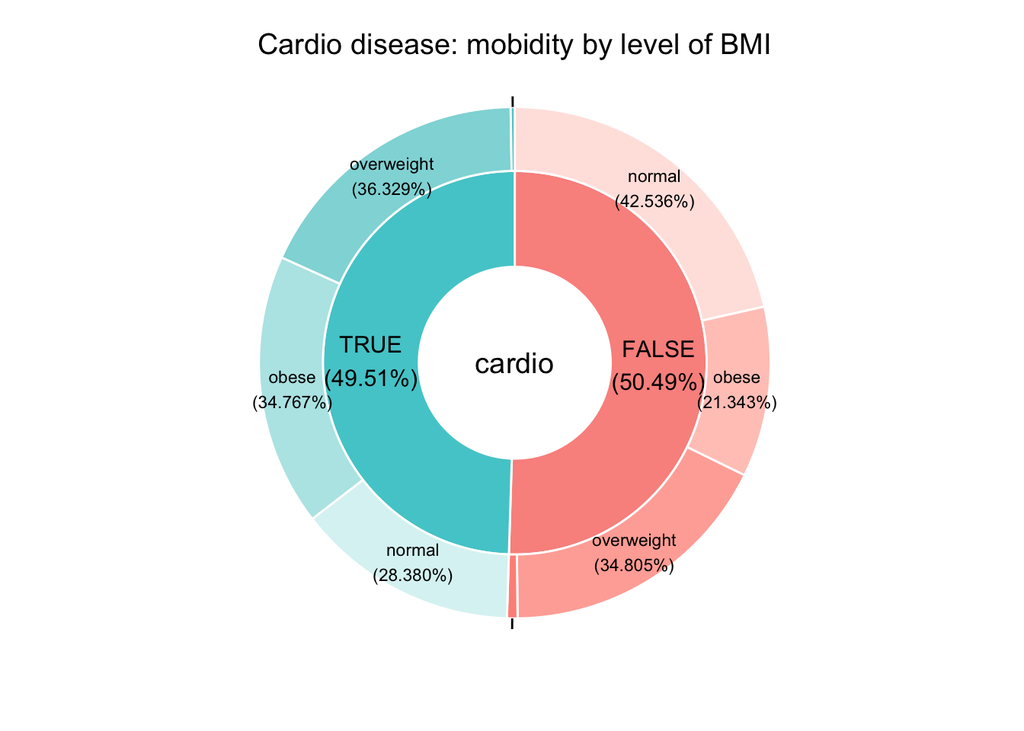

```r
PieDonut(piechart,
         aes(cardio, BMI_level, count = count),
         title = "Cardio disease: mobidity by level of BMI",
         titlesize = 5,
         r0 = 0.45,
         r1=0.9
         )
```

Interpretation of the visualization

The piechart shows that people who have a normal level of BMI are more likely not to have the disease. Also, this piechart clearly shows the actual percentage of each category and the relationships between cardio disease and levels of BMI.

# Third Visualization

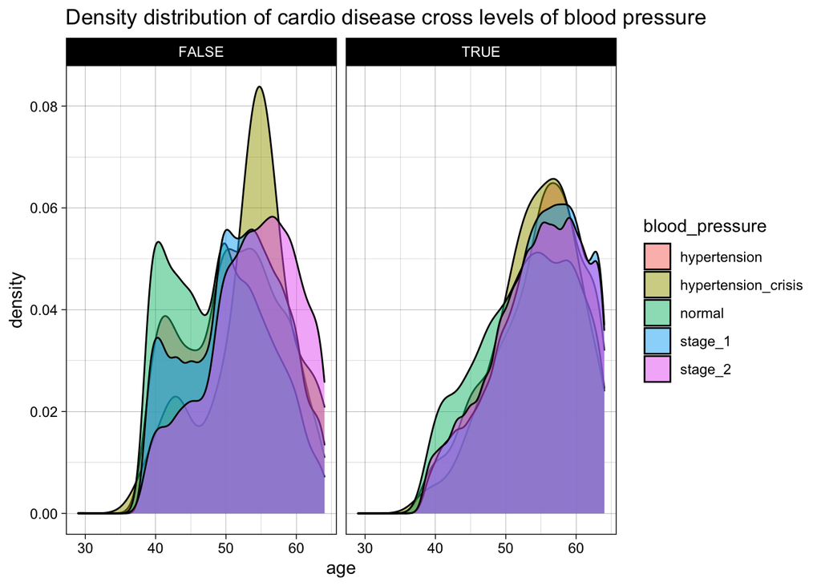

```r
cardio %>%
  ggplot(aes(x = age,
             fill = blood_pressure))+
  geom_density(alpha = .5)+
  facet_wrap(~cardio)+
  labs(title = "Density distribution of cardio disease cross levels of blood pressure")+
  theme_linedraw()
```

Interpretation of the visualization

Based on the visualization, people who have cardiovascular disease across all the levels of blood pressure are distributed in the range of age from the 50s to 60s. People don’t have the disease, the group of hypertension crisis distributed in older ages compared to other groups.